# Capstone 2: Historical EV Sales Analysis

## Sales & Charging Points over time by Country:

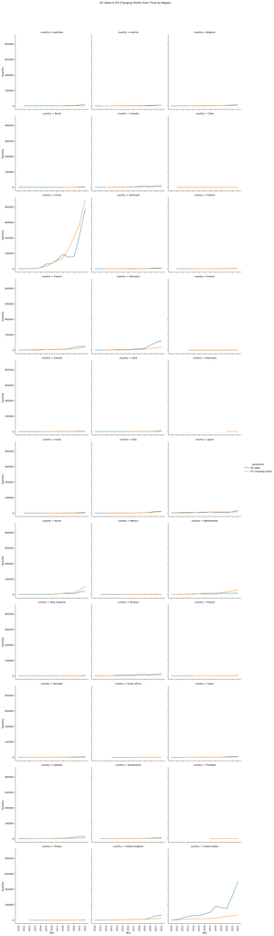

```python
# Line Graph of EV sales & EV charging points over time by region
plot = sns.relplot(x="year", y="value",
                   hue="parameter",
                   col="country",  # Specify country column to create separate graphs
                   col_wrap=3,  # Number of columns per row
                   data=df_ctry_prm_ctg,
                   kind="line",
                   errorbar=None)

# Set x-axis and y-axis labels
plot.set_axis_labels('Year', 'Quantity')  # Change 'Total Value' to your desired y-axis label

# Set the title of the plot
plot.fig.suptitle('EV Sales & EV Charging Points Over Time by Region', y=1.03)  # Adjust y for spacing

# Ensure all years are displayed on the x-axis and rotate labels
for ax in plot.axes.flat:
    ax.set_xticks(df_ctry_prm_ctg['year'].unique())
    ax.set_xticklabels(df_ctry_prm_ctg['year'].unique(), rotation=90)

# Show plot
plt.show()
```

## Insights:

- China and USA have the highest EV Sales (also have very large populations)
- Korea and Netherlandshad higher public charging point growth than EV sales.

## Growth Rate of EV sales & Charging Points over time by Country

```
           country  year           parameter  total_count  growth_rate
0        Australia  2011            EV sales         49.0          NaN
1        Australia  2012            EV sales        250.0   410.204082
2        Australia  2013            EV sales        290.0    16.000000
3        Australia  2014            EV sales       1320.0   355.172414
4        Australia  2015            EV sales       1760.0    33.333333
..             ...   ...                 ...          ...          ...
700  United States  2020            EV sales     294000.0    -9.538462
701  United States  2021  EV charging points     114000.0    15.151515
702  United States  2021            EV sales     630000.0   114.285714
703  United States  2022  EV charging points     128000.0    12.280702
704  United States  2022            EV sales     990000.0    57.142857

[705 rows x 5 columns]
```

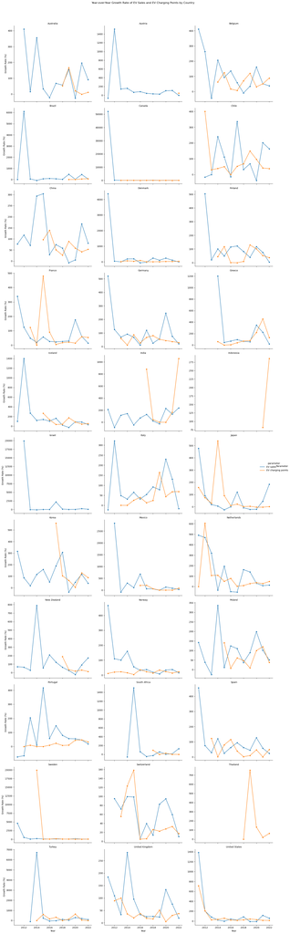

```python
# Filter the DataFrame for EV sales and EV charging points
ev_sales_charging_df = df_ctry_prm_ctg[df_ctry_prm_ctg['parameter'].isin(['EV sales', 'EV charging points'])]

# Group by region, year, and parameter, then sum the values
sum_by_region_year_parameter = ev_sales_charging_df.groupby(['country', 'year', 'parameter'])['value'].sum().reset_index(name='total_count')

# Calculate the year-over-year growth rate for each country
sum_by_region_year_parameter['growth_rate'] = sum_by_region_year_parameter.groupby(['country', 'parameter'])['total_count'].pct_change() * 100

# Display the DataFrame with growth rates
print(sum_by_region_year_parameter)

# Plotting the growth rate line graph at the country level
plt.figure(figsize=(15, 10))
g = sns.relplot(x="year", y="growth_rate",
                hue="parameter",
                col="country",  # Specify country column to create separate graphs
                col_wrap=3,  # Number of columns per row
                data=sum_by_region_year_parameter,
                kind="line",
                marker='o',
                facet_kws={'sharey': False})  # Allow different y-axis scales for each subplot

# Adjust the titles and labels for readability
g.set_titles("{col_name}")
g.set_axis_labels("Year", "Growth Rate (%)")
g.add_legend(title="Parameter")
plt.suptitle('Year-over-Year Growth Rate of EV Sales and EV Charging Points by Country', y=1.02)
plt.show()
```

## BEV vs PHEV Sales Over Time

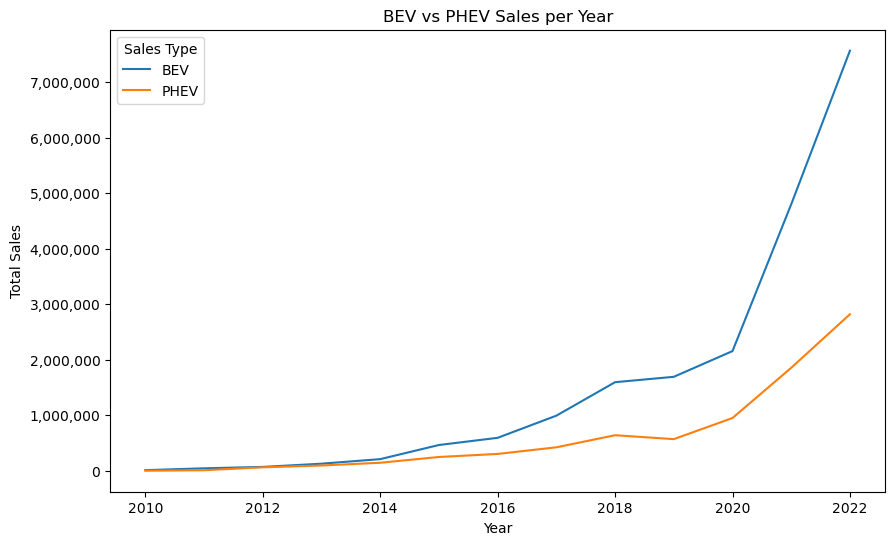

```python
# Filter the DataFrame for EV and PHEV sales
ev_phev_sales_df = df_ctry_prm_ctg[df_ctry_prm_ctg['parameter'] == 'EV sales']

# Group by year and powertrain, then sum the values
sum_by_year_powertrain = ev_phev_sales_df.groupby(['year', 'powertrain'])['value'].sum().reset_index(name='total_count')

# Custom formatter function to avoid scientific notation and add commas
def comma_formatter(x, pos):
    return '{:,.0f}'.format(x)

# Plotting the line graph
plt.figure(figsize=(10, 6))
sns.lineplot(data=sum_by_year_powertrain, x='year', y='total_count', hue='powertrain')
plt.title('BEV vs PHEV Sales per Year')
plt.xlabel('Year')
plt.ylabel('Total Sales')
plt.legend(title='Sales Type')

# Apply comma formatter to y-axis
plt.gca().yaxis.set_major_formatter(FuncFormatter(comma_formatter))

# Show plot
plt.show()
```

## Insights:

- BEV sales has been greater than PHEV sales since 2013
- Both BEV and PHEV sales significantly increased from 2020 - 2022

## Total Count of EV Type by Country

```python
# Filter the DataFrame for parameter = 'EV sales'
ev_sales_df = df_ctry_prm_ctg[df_ctry_prm_ctg['parameter'] == 'EV sales']

# Group by country and powertrain, then sum the values
sum_by_country_powertrain = ev_sales_df.groupby(['country', 'powertrain'])['value'].sum().reset_index(name='total_count')

# Sort the DataFrame by total count in descending order
sum_by_country_powertrain_sorted = sum_by_country_powertrain.sort_values(by='total_count', ascending=False)

# Display the result
print(sum_by_country_powertrain_sorted)
```

```
          country powertrain  total_count
12          China        BEV   11944255.0
13          China       PHEV    3141173.0
60  United States        BEV    2375000.0
20        Germany        BEV    1253722.0
21        Germany       PHEV    1027844.0
..            ...        ...          ...
10          Chile        BEV       1704.0
48   South Africa        BEV       1374.0
11          Chile       PHEV       1268.0
49   South Africa       PHEV       1006.0
27          India       PHEV        123.0

[62 rows x 3 columns]
```

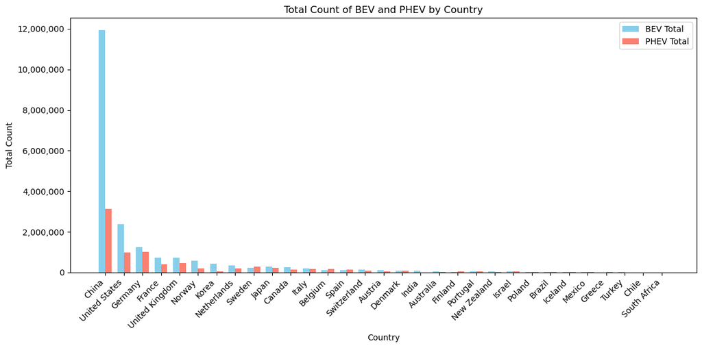

```python
# Filter the DataFrame for BEV and PHEV separately
bev_df = sum_by_country_powertrain_sorted[sum_by_country_powertrain_sorted['powertrain'] == 'BEV']
phev_df = sum_by_country_powertrain_sorted[sum_by_country_powertrain_sorted['powertrain'] == 'PHEV']

# Create new columns for BEV Total and PHEV Total
sum_by_country_powertrain_sorted['BEV Total'] = bev_df.groupby('country')['total_count'].transform('sum')
sum_by_country_powertrain_sorted['PHEV Total'] = phev_df.groupby('country')['total_count'].transform('sum')

# Define colors for BEV and PHEV bars
bev_color = 'skyblue'
phev_color = 'salmon'

# Unique countries
countries = sum_by_country_powertrain_sorted['country'].unique()

# Calculate BEV and PHEV totals per country
bev_totals = [sum_by_country_powertrain_sorted[sum_by_country_powertrain_sorted['country'] == country]['BEV Total'].sum() for country in countries]
phev_totals = [sum_by_country_powertrain_sorted[sum_by_country_powertrain_sorted['country'] == country]['PHEV Total'].sum() for country in countries]

# X-axis positions
x = np.arange(len(countries))

# Bar width
bar_width = 0.35

# Custom formatter function to add commas
def comma_formatter(x, pos):
    return '{:,.0f}'.format(x)

# Plotting BEV and PHEV totals by country
fig, ax = plt.subplots(figsize=(12, 6))

# BEV bars
bar1 = ax.bar(x - bar_width / 2, bev_totals, bar_width, label='BEV Total', color=bev_color)

# PHEV bars
bar2 = ax.bar(x + bar_width / 2, phev_totals, bar_width, label='PHEV Total', color=phev_color)

# Set x-axis labels
ax.set_xlabel('Country')
ax.set_ylabel('Total Count')
ax.set_title('Total Count of BEV and PHEV by Country')
ax.set_xticks(x)
ax.set_xticklabels(countries, rotation=45, ha='right')

# Apply comma formatter to y-axis
ax.yaxis.set_major_formatter(FuncFormatter(comma_formatter))

# Add legend
ax.legend()

# Adjust layout
fig.tight_layout()

# Show plot
plt.show()
```

## Insights:

- China has the highest sales in both BEV and PHEV, followed by USA then Germany
- Sweden, Belgium, Spain, Finland are the only countries with higher PHEV sales than BEV

```python
# Ignore all warnings
warnings.filterwarnings("ignore")
```